# WAAVP Sample Sizes

To look at the effect of tweaking these parameters see the online app [here](https://ucphepi.shinyapps.io/waavp_typologies/)

## Ruminants

We are using the following parameter values:

```
## # A tibble: 12 x 10
##    Species Protocol Target Delta mutype     N    mu    k1    k2   cor
##    <chr>   <chr>     <dbl> <dbl> <chr>  <dbl> <dbl> <dbl> <dbl> <dbl>
##  1 Calves  Clinical     99     9 low       12    10   1.5   0.4   0.1
##  2 Cattle  Clinical     99     9 low       12    10   1.1   0.5   0.1
##  3 Sheep   Clinical     99     9 low       12    10   1.2   0.7   0.5
##  4 Calves  Clinical     99     9 high       6    50   1.5   0.4   0.1
##  5 Cattle  Clinical     99     9 high       6    50   1.1   0.5   0.1
##  6 Sheep   Clinical     99     9 high       6    50   1.2   0.7   0.5
##  7 Calves  Research     99     4 low       25    10   1.5   0.4   0.1
##  8 Cattle  Research     99     4 low       25    10   1.1   0.5   0.1
##  9 Sheep   Research     99     4 low       25    10   1.2   0.7   0.5
## 10 Calves  Research     99     4 high      15    50   1.5   0.4   0.1
## 11 Cattle  Research     99     4 high      15    50   1.1   0.5   0.1
## 12 Sheep   Research     99     4 high      15    50   1.2   0.7   0.5
```

### Clinical protocols

Calves - high mean:

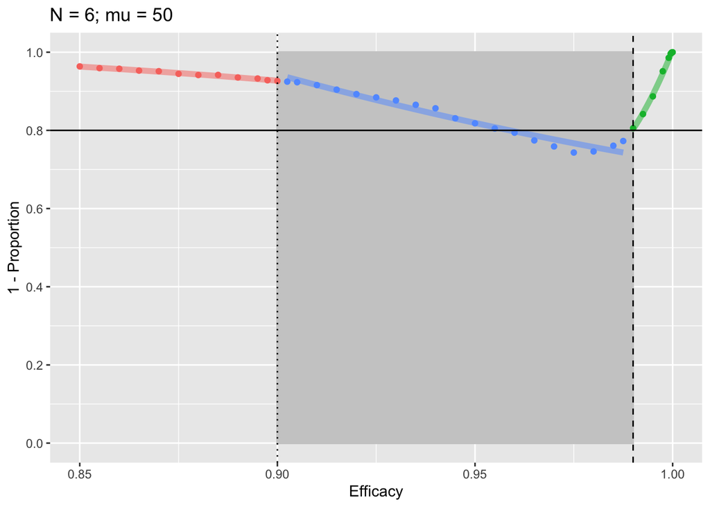

Calves - low mean:

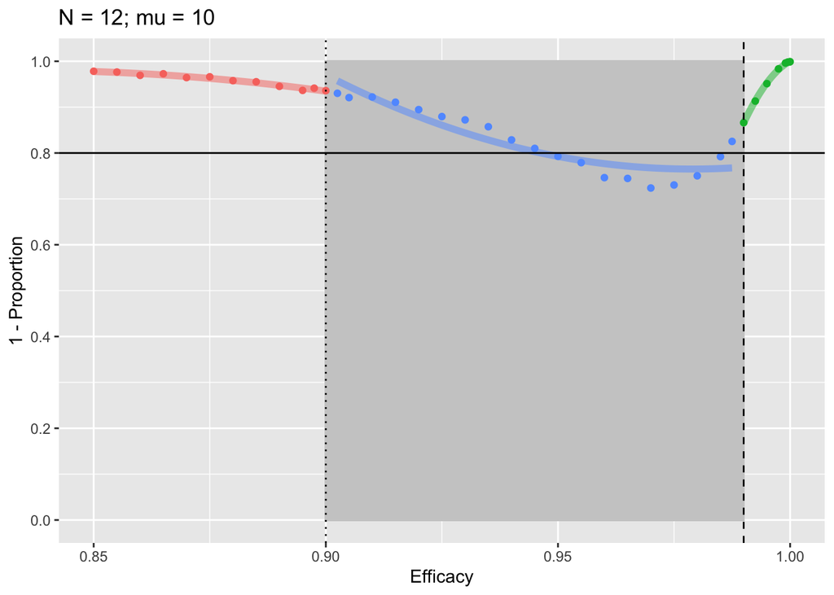

Cattle - high mean:

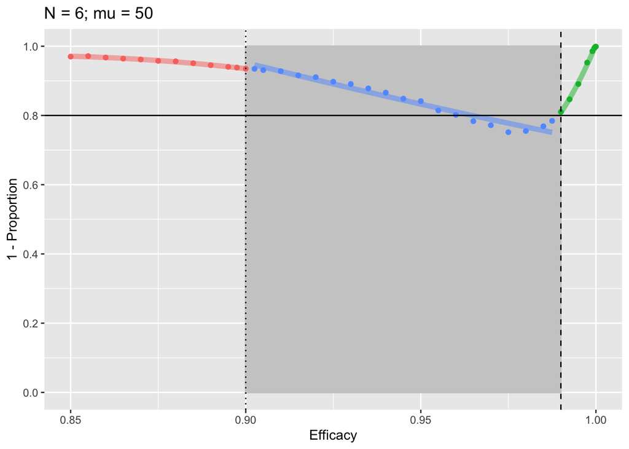

Cattle - low mean:

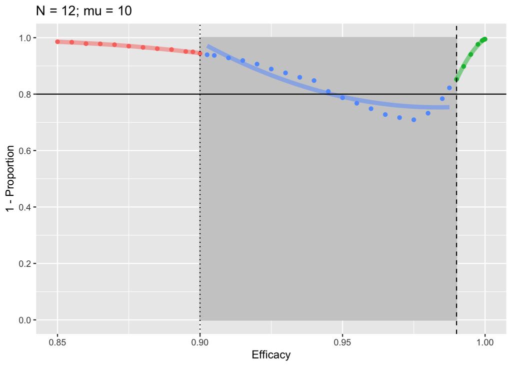

Sheep - high mean:

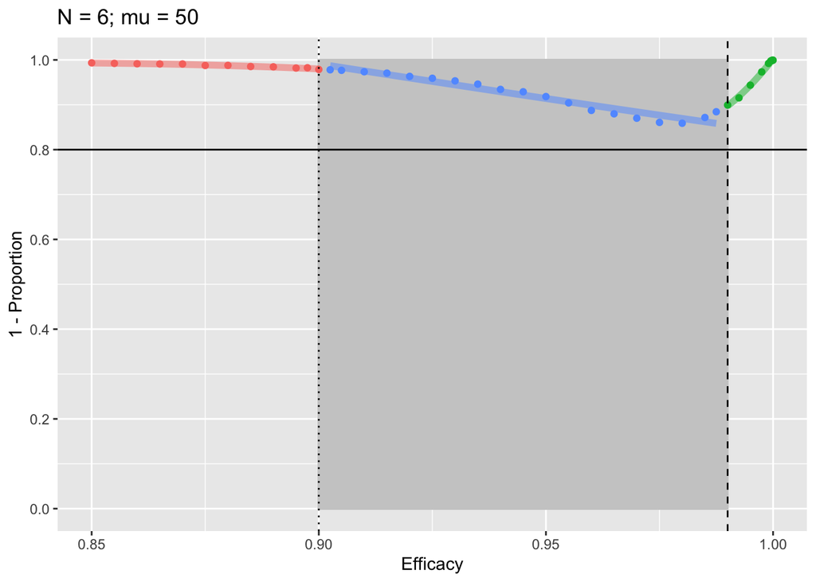

Sheep - low mean:

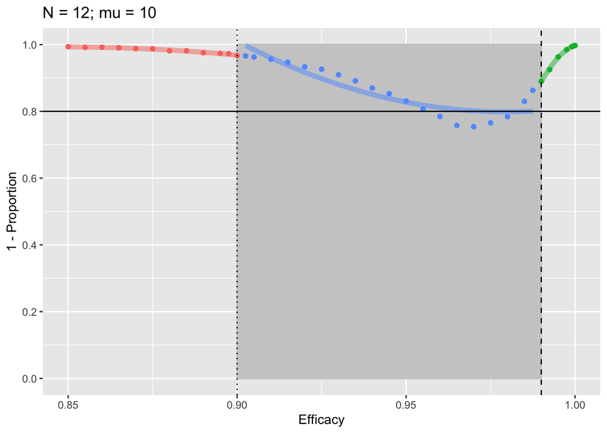

### Research protocols

Calves - high mean:

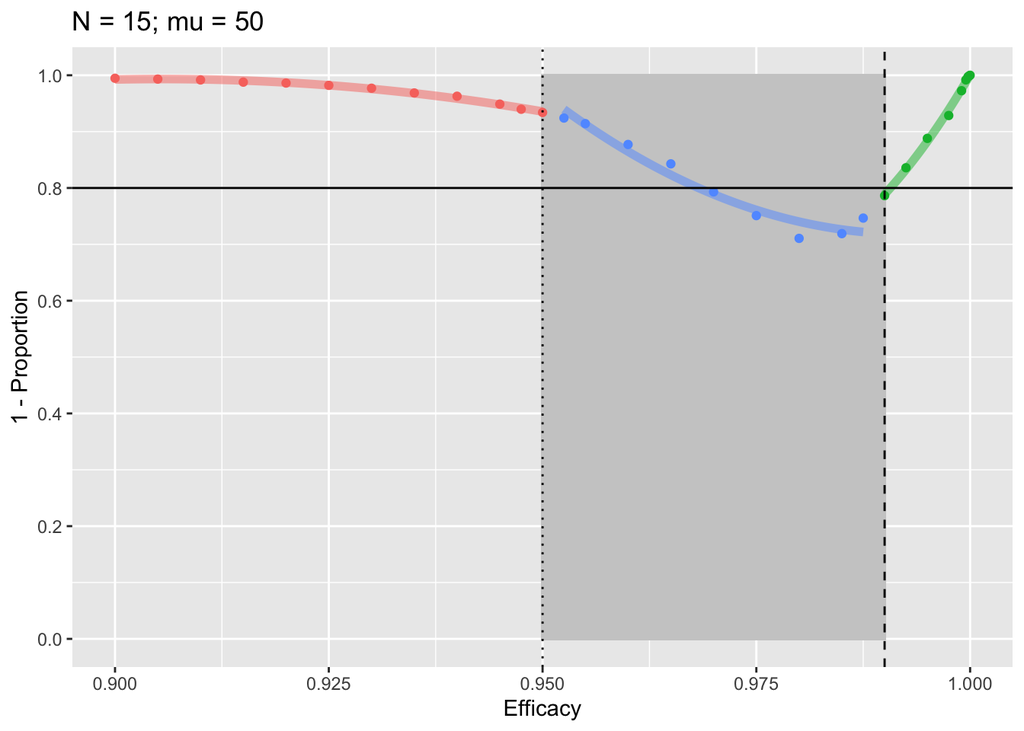

Calves - low mean:

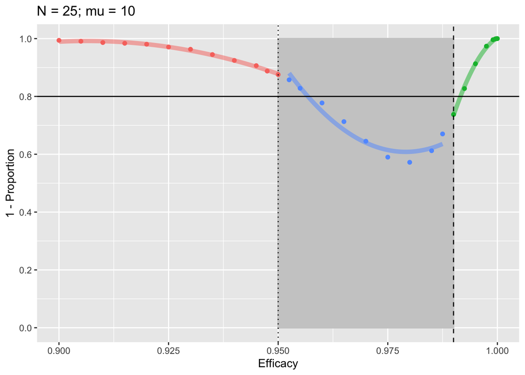

Cattle - high mean:

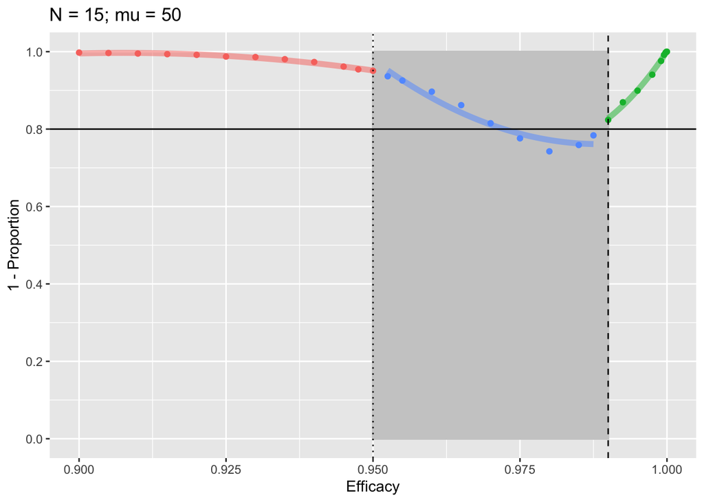

Cattle - low mean:

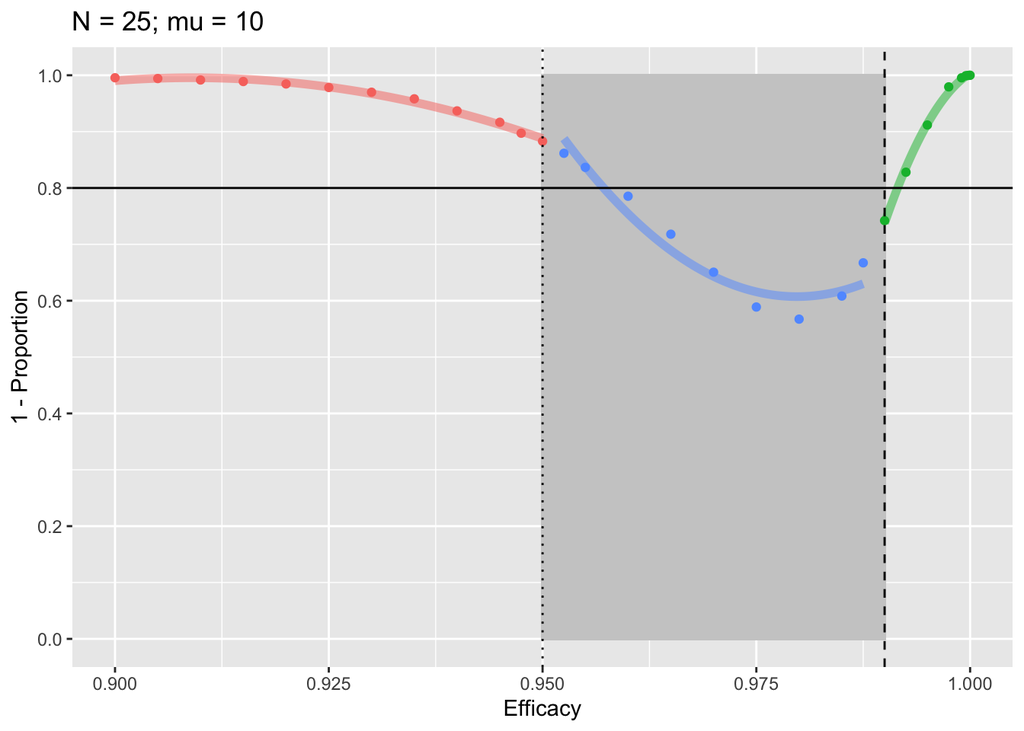

Sheep - high mean:

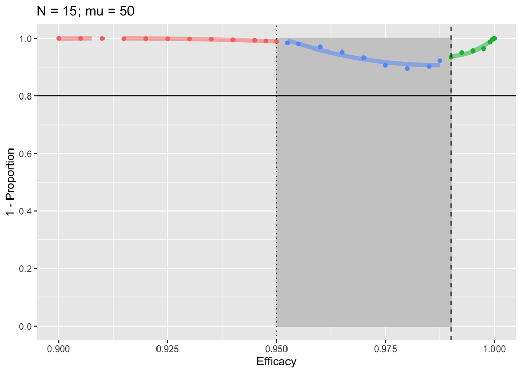

Sheep - low mean:

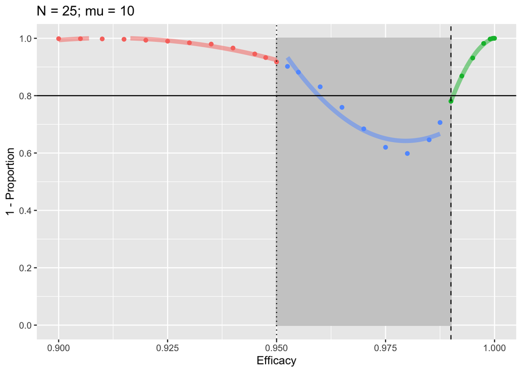

## Equine

We are using the following parameter values:

```
## # A tibble: 8 x 10
##   Protocol Drug     Target Delta mutype     N    mu    k1    k2   cor
##   <chr>    <chr>     <dbl> <dbl> <chr>  <dbl> <dbl> <dbl> <dbl> <dbl>
## 1 Clinical AVM        99.9   7.9 low       12    10   0.6   0.6   0.5
## 2 Clinical AVM        99.9   7.9 high       6    50   0.6   0.6   0.5
## 3 Clinical Pyrantel   98    15   low       15    10   0.6   0.6   0.5
## 4 Clinical Pyrantel   98    15   high       9    50   0.6   0.6   0.5
## 5 Research AVM        99.9   2.9 low       25    10   0.6   0.6   0.5
## 6 Research AVM        99.9   2.9 high      15    50   0.6   0.6   0.5
## 7 Research Pyrantel   98    10   low       22    10   0.6   0.6   0.5
## 8 Research Pyrantel   98    10   high      12    50   0.6   0.6   0.5
```

### Clinical protocols

Pyrantel - high mean:

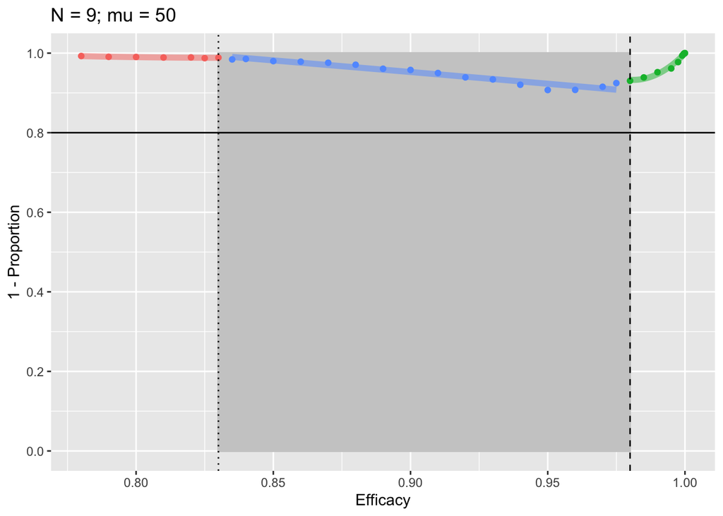

Pyrantel - low mean:

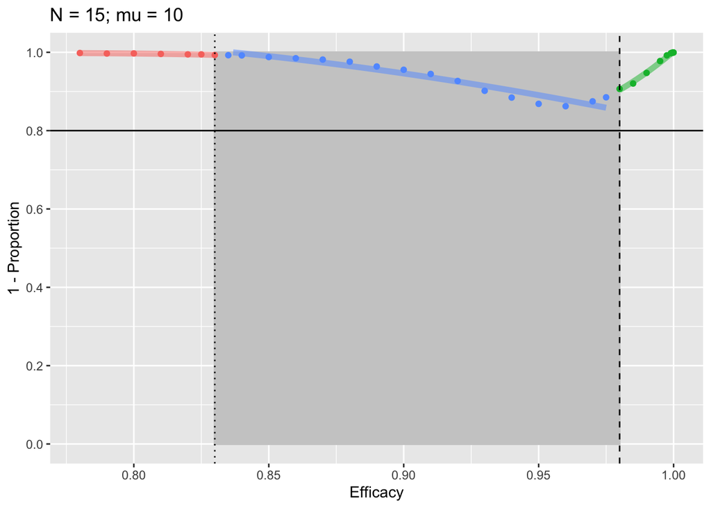

Mox - high mean:

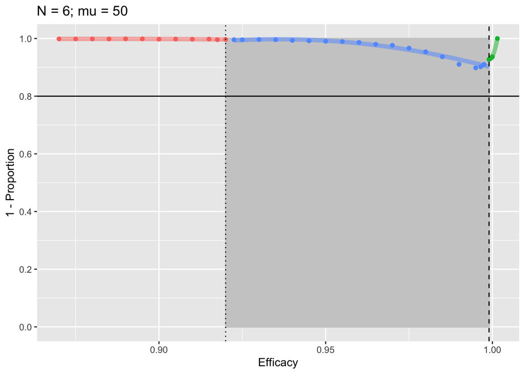

Mox - low mean:

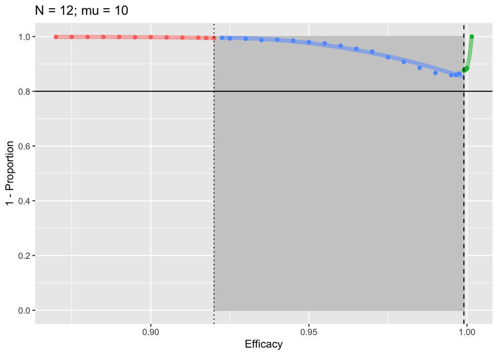

### Research protocols

Pyrantel - high mean:

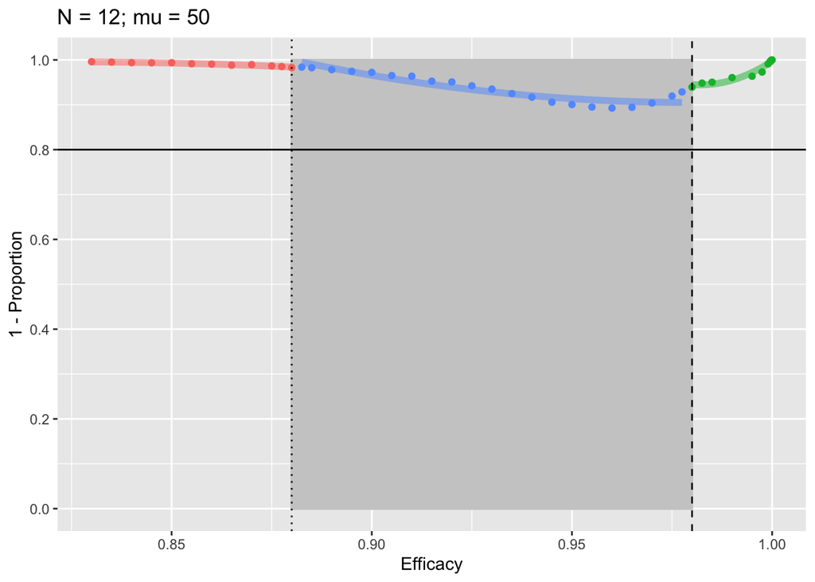

Pyrantel - low mean:

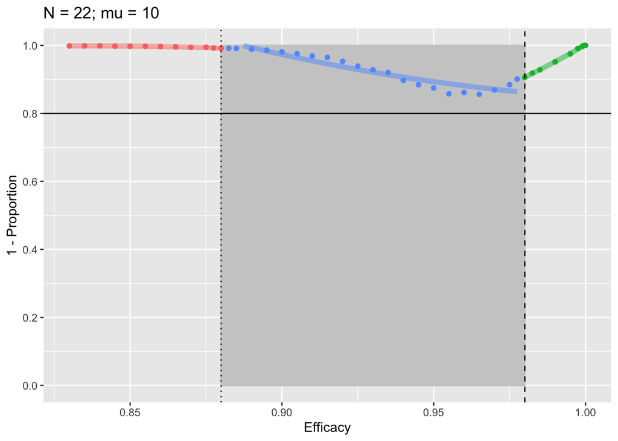

Mox - high mean:

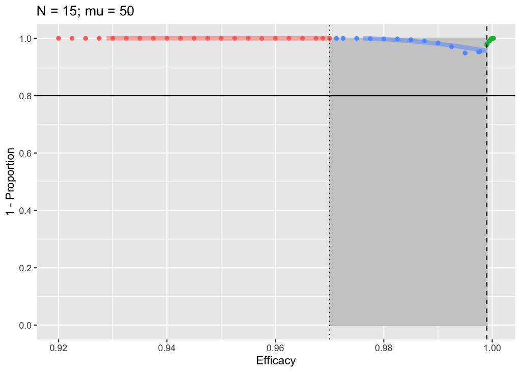

Mox - low mean:

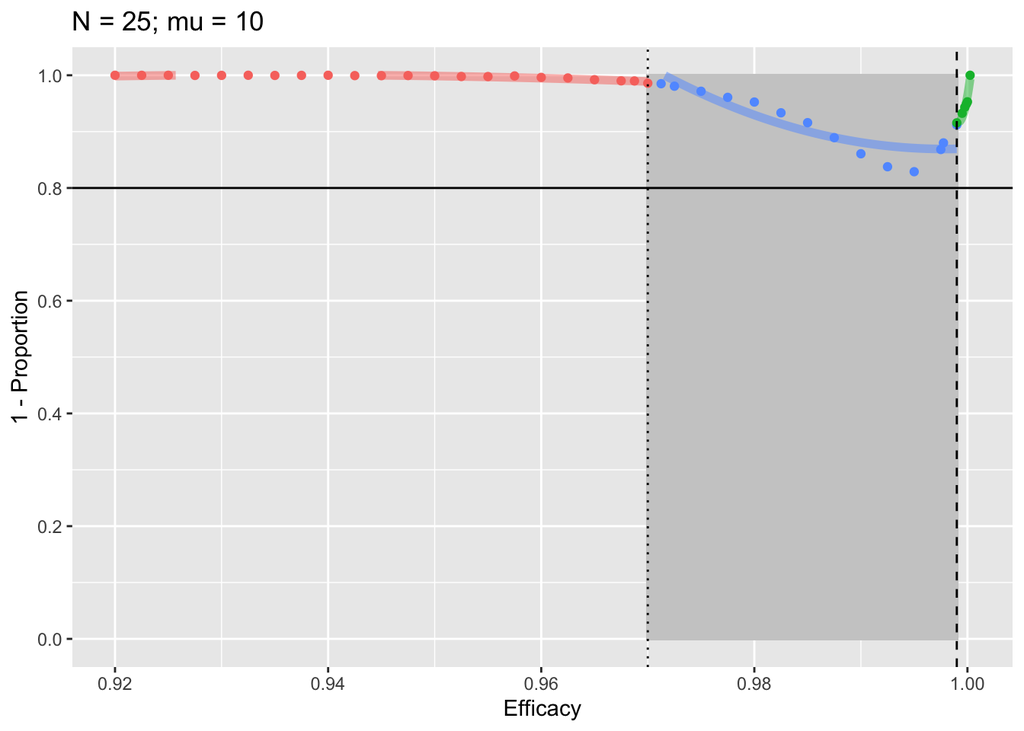

## Online app

To look at the effect of tweaking these parameters see the online app [here](https://ucphepi.shinyapps.io/waavp_typologies/)